# ACTIVIDAD 2 - UD2

# Actividad 2 - UD2

Carga el dataset **titanic** con el comando y haz un sumario

```r
#install.packages("titanic")
library(titanic)
data("titanic_train")
df <- titanic_train
head(df)
str(df)
```

[output not shown]

- Transforma las variables que sean factores en factores. Si son ordinales usa *ordered* para crear factores ordenados. Recuerda usar lapply.

```r
summary(df)

df[c("Pclass","SibSp","Parch")] <- lapply(df[c("Pclass","SibSp","Parch")],ordered)
df[c("Sex","Cabin","Ticket","Name","Embarked","Survived")] <- lapply(df[c("Sex","Cabin","Ticket","Name","Embarked","Survived")],factor)

summary(df)
str(df)
```

[output not shown]

- Representa en un qplot la edad frente a la tarifa, y en un segundo qplot lo mismo pero con la clave de la clase en la que viajaban. Represéntalo a su vez factorizándolo por *Sex* y *Embarked*

```r
library(ggplot2)

qplot(Age, Fare, data=df)
qplot(Age, Fare, data=df, colour=Pclass)
```

[output not shown]

```r
qplot(Age, Fare, data=df, colour=Pclass, facets=~Sex+Embarked)
qplot(Age, Fare, data=df, colour=Pclass, facets=Sex~Embarked)
```

[output not shown]

```r
ggplot(df, aes(x=Age, y=Fare)) + geom_point()
ggplot(df, aes(x=Age, y=Fare)) + geom_hex()
ggplot(df, aes(x=Age, y=Fare)) + geom_smooth()
ggplot(df, aes(x=Age, y=Fare)) + geom_line()
ggplot(df, aes(x=Age, y=Fare)) + geom_density2d()
```

[output not shown]

- Pinta un boxplot de la edad agrupado según *Sex*

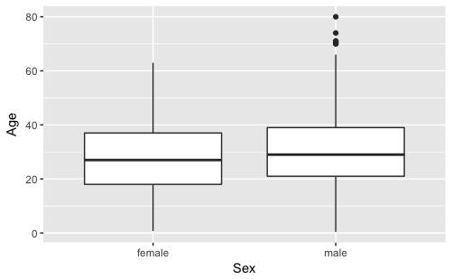

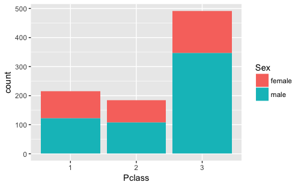

- Pinta la supervivencia en función de la categoría *Sex*, ¿qué observas?

[figure not shown]

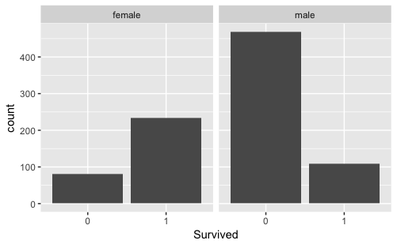

- Pinta la supervivencia en función de la categoría *Pclass*, ¿qué se aprecia?

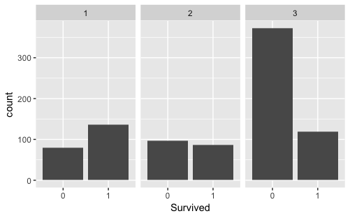

- Crea un histograma de *Age*, ¿qué observas?

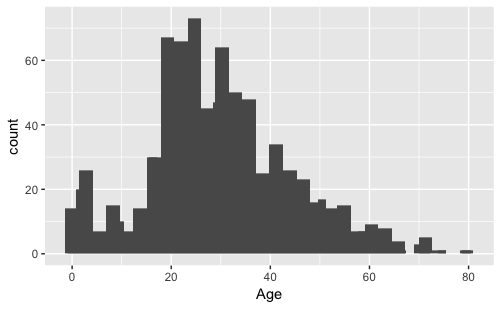

- Crea una agrupación de los datos usando `dplyr` de *Sex* y *Pclass*. Haz sumarios de media, conteo y mediana. ¿Qué podrías decir de los resultados? ¿Hay suficiente muestra para sacar conclusiones en todas las categorías creadas al combinar la edad y la clase?

| Sex | Pclass | Media | Mediana | Conteo |
| --- | --- | --- | --- | --- |
| female | 1 | 0.9680851 | 1.0 | 94 |
| female | 2 | 0.9210526 | 1.0 | 76 |
| female | 3 | 0.5000000 | 0.5 | 144 |
| male | 1 | 0.3688525 | 0.0 | 122 |
| male | 2 | 0.1574074 | 0.0 | 108 |
| male | 3 | 0.1354467 | 0.0 | 347 |